# Effects of Temperature and Wind on Arrival Time of Trans-Gulf Migrants

Gone-Fishing

2022-12-15

# Introduction

The term trans-Gulf migrants or TGMs, refer to species of birds that fly non-stop over the Gulf of Mexico and arrive on land between Texas and Florida. They are part of a larger group of birds that undertake long-distance migrations from Central and South America to more temperate latitudes.

The time of arrival of these TGMs have quite a large effect on their rates of survival. One example of this is the red knot, or *Calidris canutus rufa*. In the spring, this species of bird travels from Tierra del Fuego to the Delaware Bay (a 30,000 km trip), and usually bulks up on horseshoe crab eggs in Delaware Bay before leaving to breed in Arctic polar deserts. From 1997-2002, a higher proportion of knots did not reach threshold departure masses, and the population size dropped from 51,000 to 37,000. This drop in population is assumed to be a result of birds arriving later in Delaware, after the horseshoe crab eggs had already been depleted. (Baker et al. (2004))

Other research has also shown that survival rates are reduced by cold weather and high density, (Cook et al. (2021)) and as climate change continues to cause abnormal temperature and weather fluctuation, TGM survival rate also fluctuates.

In 2002, Cornell Laboratory of Ornithology and the National Audubon society created a program called eBird that allows citizen scientists and birders to share their observations, creating a database for bird sightings. The creation of this program has the potential to be an incredibly important tool in the study of avian biology.

Our goal with this project is to use eBird and meteorological data to understand the effect of local weather conditions when TGMs arrive in Massachusetts.

# Methods

First we chose five trans-Gulf migrant (TGM) bird species to study, each bird species being from different families. The species we chose are as follows: Common Nighthawk (Chordeiles minor), Scarlet Tanager (Piranga olivacea), Cerulean Warbler (Setophaga cerulea), Baltimore Oriole (Icterus galbula), and Red-eyed vireo (Vireo olivaceus). Using the occ_data() function from rgbif, which searches GBIF occurrences, we then download the occurrence data for these species. We then used logistic modeling operations to predict the Julian day when 25% of the population arrives, aka the arrival time, for each year and for each species. Three locations were chosen along the assumed flight path of the birds, Mobile, AL being on the Gulf at the beginning of the route, Boston, MA being the end destination, and Charlotte, NC being about the middle of the journey. We used weather data from the NOAA website with the parameters of minimum and maximum temperature in tenths of degrees celsius (tmin), average wind velocity in m/s (awnd), and direction of fastest 2-minute wind (wdf2). To evaluate the effect of weather parameters on arrival time we used a linear mixed-effect modeling using lme4 package and lme4() function. Lastly we use the anova() function from the car package to look at the interactions and assesses the significance of the fixed effects.

# Results

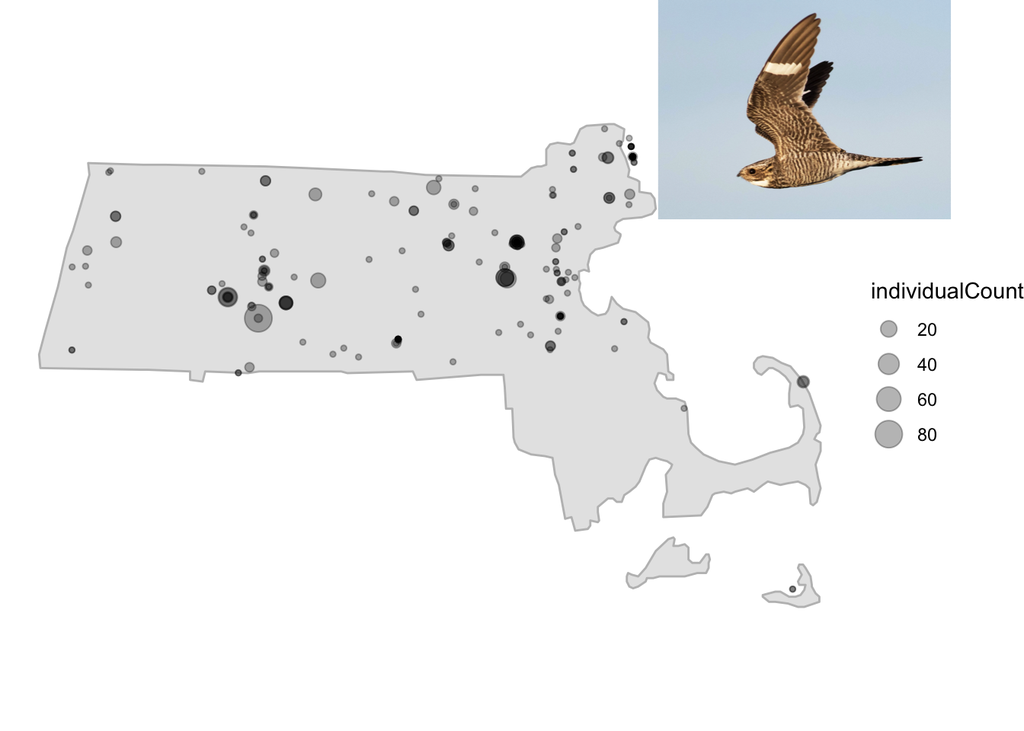

**Fig. 1.** Occurence of *Chordeiles minor* in Massachusetts from 2018. Data from eBird counts.

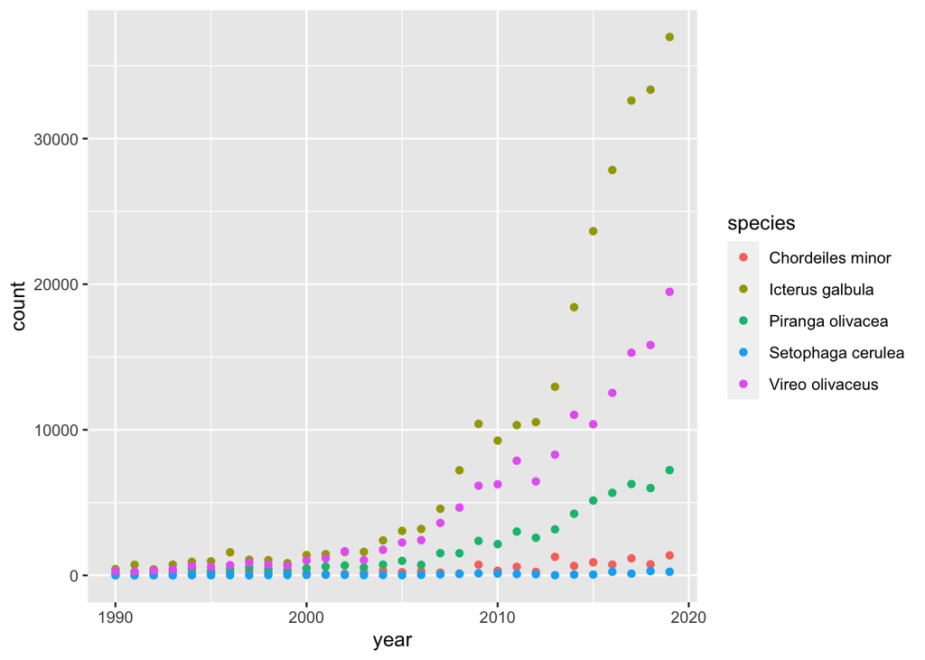

**Fig. 2.** Occurence of five TGM species in Massachusetts from 1990 to 2019.

From 1990 to 2019, sightings of all five species of TGMs were observed more frequently. *Icterus galbula*, *Vireo olivaceus*, and *Piranga olivacea* counts in particular increased in the last decade.

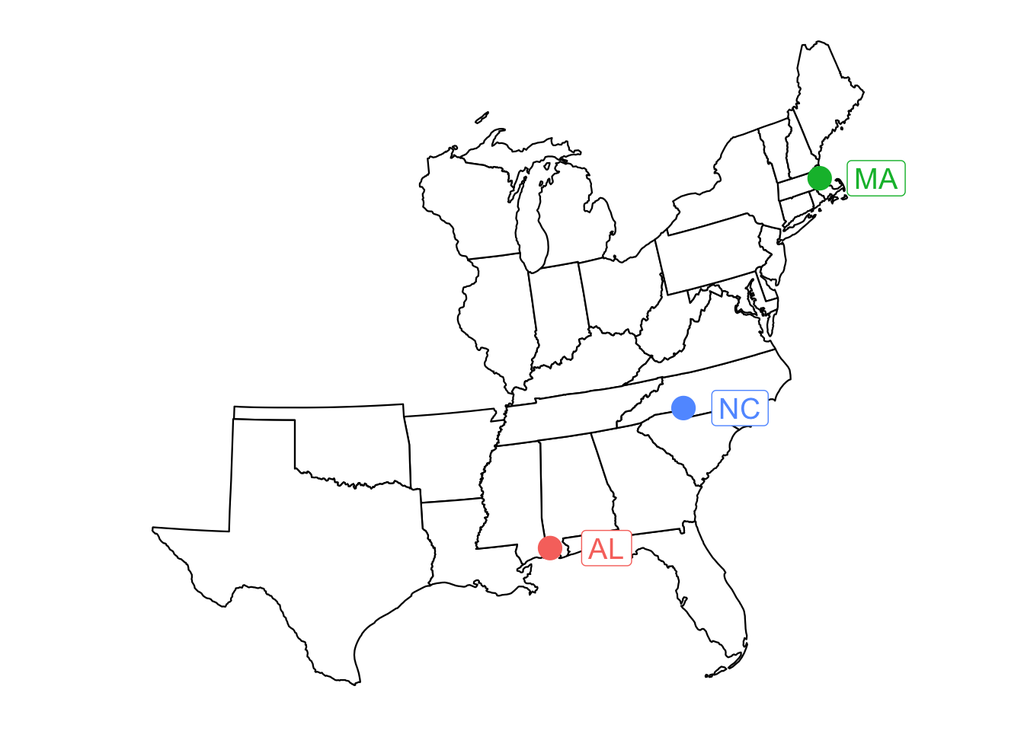

**Fig. 3.** Map of flight path of TGMs from first landing in the US in Mobile, AL to final destination in Boston, MA.

## Chordeiles minor

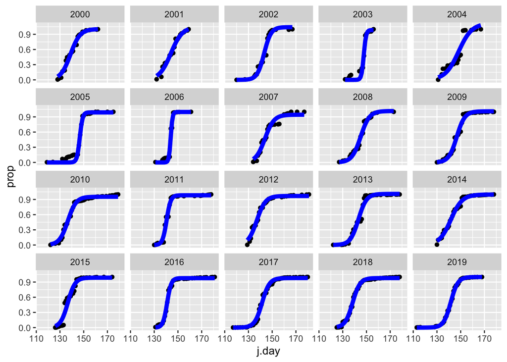

**Fig. 4.** Proportion of the population of *Chordeiles minor* that has arrived in Boston, MA by the given Julian day. Logistic models plotted in blue to estimate the arrival date.

The arrival data for *Chordeiles minor* is between 130 and 150 Julian days. This date can be closely predicated with a logistical model curve.

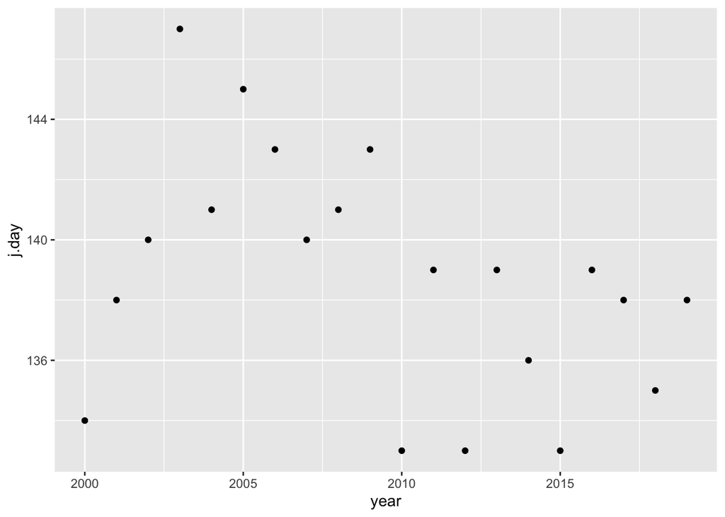

**Fig. 5.** Julian day from each year corresponding to the arrival of 25% of the *Chordeiles minor* population to Boston, MA.

When 25% of the TGM species has arrived in Boston, MA, the species can be said to have arrived to its spring range. The arrival dates for *Chordeiles minor* are scattered from 130 to 150, but show a slight downward trend toward a lower Julian date.

**Table 1.** Fit values for nested models of the most complicated linear mixed-effect model.

|  | (Intercept) | wk.tmax | wk.tmin | wk.wvec | wk.tmax:wk.tmin | wk.tmax:wk.wvec | wk.tmin:wk.wvec | wk.tmax:wk.tmin:wk.wvec | df | logLik | AICc | delta | weight |
| --- | --- | --- | --- | --- | --- | --- | --- | --- | --- | --- | --- | --- | --- |
| 1 | 137.9553 | -0.0549176 | 0.1154581 | -0.1264421 | NA | NA | NA | NA | 6 | -166.6635 | 346.9120 | 0.00000 | 0.9974206630 |
| 5 | 138.2267 | -0.0417184 | 0.0861929 | -0.2476043 | NA | NA | 0.0009825 | NA | 7 | -172.1689 | 360.4916 | 13.57963 | 0.0011222737 |
| 3 | 138.1002 | -0.0454151 | 0.0935159 | -0.2960087 | NA | 0.0007775 | NA | NA | 7 | -172.4033 | 360.9605 | 14.04852 | 0.0008877292 |
| 2 | 151.2899 | -0.0966278 | -0.0376309 | -0.1301467 | 0.0005098 | NA | NA | NA | 7 | -172.8475 | 361.8489 | 14.93692 | 0.0005693341 |

The first model shown in the table including minimum temperature, maximum temperature, and wind vector fits this data set best.

## Piranga olivacea

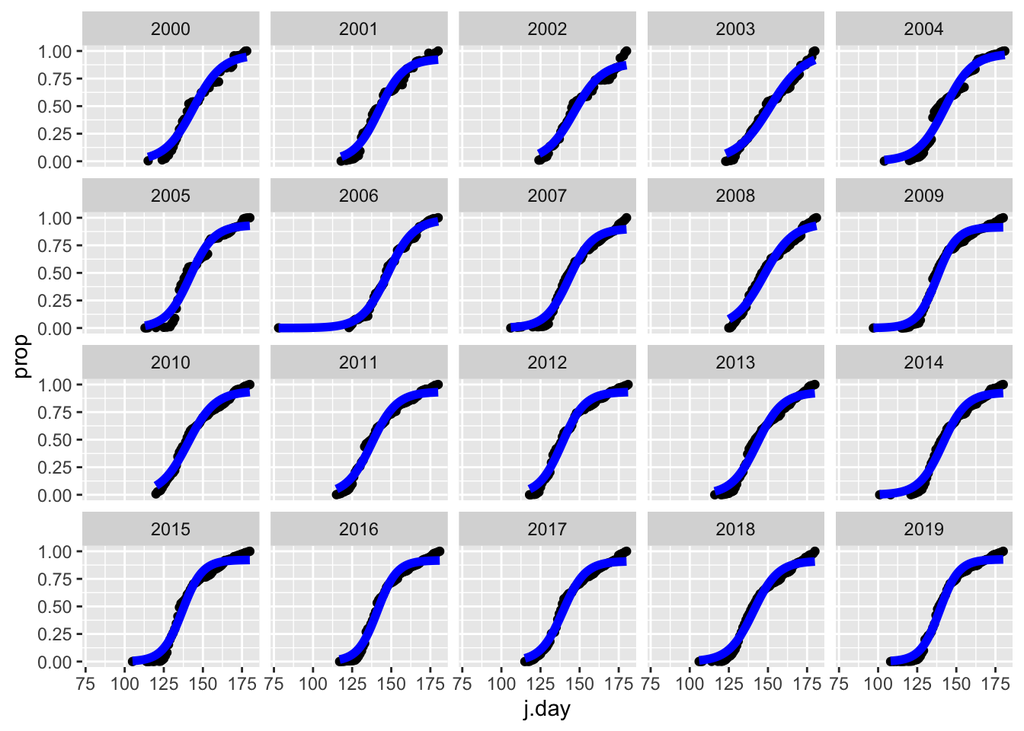

**Fig. 6.** Proportion of the population of *Piranga olvivacea* that has arrived in Boston, MA by the given Julian day. Logistic models plotted in blue to estimate the arrival date.

The arrival data for *Piranga olivacea* is between 125 and 140 Julian days. This date can be closely predicated with a logistical model curve.

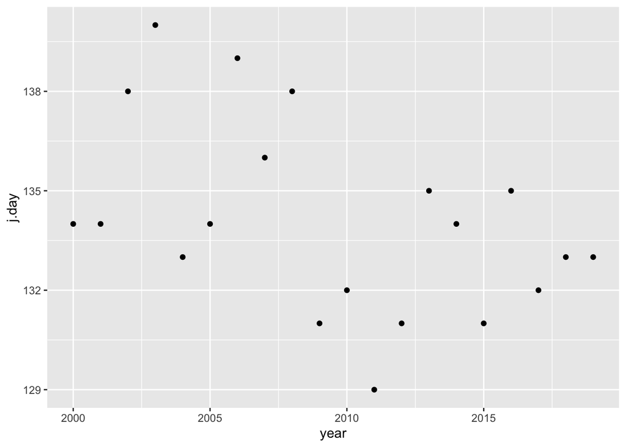

**Fig. 7.** Julian day from each year corresponding to the arrival of 25% of the *Piranga olivacea* population to Boston, MA.

When 25% of the TGM species has arrived in Boston, MA, the species can be said to have arrived to its spring range. The arrival dates for *Piranga olivacea* are scattered from 129 to 140, but show a slight downward trend toward a lower Julian date.

**Table 2.** Fit values for nested models of the most complicated linear mixed-effect model.

|  | (Intercept) | wk.tmax | wk.tmin | wk.wvec | wk.tmax:wk.tmin | wk.tmax:wk.wvec | wk.tmin:wk.wvec | wk.tmax:wk.tmin:wk.wvec | df | logLik | AICc | delta | weight |
| --- | --- | --- | --- | --- | --- | --- | --- | --- | --- | --- | --- | --- | --- |
| 1 | 132.3807 | -0.0279394 | 0.0744336 | -0.1223675 | NA | NA | NA | NA | 6 | -151.6277 | 316.8404 | 0.00000 | 0.9942594594 |
| 5 | 133.4505 | -0.0149691 | 0.0375893 | -0.3274015 | NA | NA | 0.0016514 | NA | 7 | -156.0625 | 328.2789 | 11.43850 | 0.0032633238 |
| 3 | 133.1881 | -0.0209553 | 0.0515830 | -0.3960445 | NA | 0.0011642 | NA | NA | 7 | -156.6962 | 329.5462 | 12.70578 | 0.0017317071 |
| 2 | 145.3608 | -0.0710078 | -0.0837190 | -0.1381142 | 0.0005543 | NA | NA | NA | 7 | -157.5389 | 331.2317 | 14.39137 | 0.0007455097 |

The first model shown in the table including minimum temperature, maximum temperature, and wind vector fits this data set best.

## Setophaga cerulea

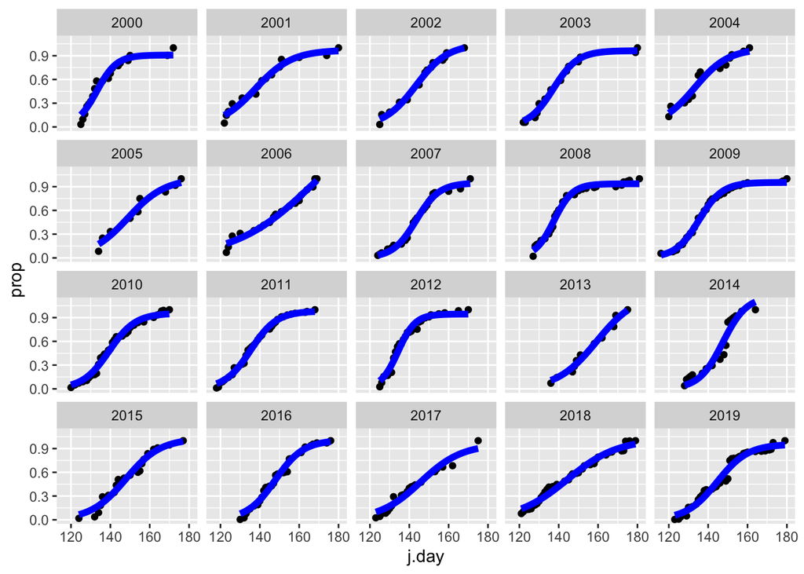

**Fig. 8.** Proportion of the population of *Setophaga cerulea* that has arrived in Boston, MA by the given Julian day. Logistic models plotted in blue to estimate the arrival date.

The arrival data for *Setophaga cerulea* is between 120 and 150 Julian days. This date can be closely predicated with a logistical model curve.

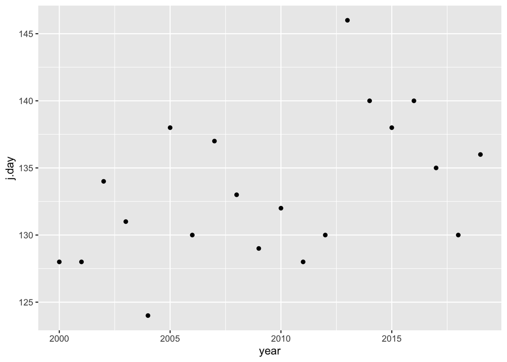

**Fig. 9.** Julian day from each year corresponding to the arrival of 25% of the *Setophaga cerulea* population to Boston, MA.

When 25% of the TGM species has arrived in Boston, MA, the species can be said to have arrived to its spring range. The arrival dates for *Setophaga cerulea* are scattered from 120 to 150, but show a slight upward trend toward a higher Julian date.

**Table 3.** Fit values for nested models of the most complicated linear mixed-effect model.

|  | (Intercept) | wk.tmax | wk.tmin | wk.wvec | wk.tmax:wk.tmin | wk.tmax:wk.wvec | wk.tmin:wk.wvec | wk.tmax:wk.tmin:wk.wvec | df | logLik | AICc | delta | weight |
| --- | --- | --- | --- | --- | --- | --- | --- | --- | --- | --- | --- | --- | --- |
| 1 | 125.2422 | -0.0325573 | 0.1398293 | -0.2055003 | NA | NA | NA | NA | 6 | -184.5484 | 382.6818 | 0.00000 | 0.994158453 |
| 5 | 125.6165 | -0.0575421 | 0.1911183 | 0.1188959 | NA | NA | -0.0028364 | NA | 7 | -188.8750 | 393.9039 | 11.22209 | 0.003635876 |
| 2 | 104.4826 | 0.0379271 | 0.4136663 | -0.2020668 | -0.0009789 | NA | NA | NA | 7 | -190.0589 | 396.2716 | 13.58985 | 0.001112902 |
| 3 | 125.7767 | -0.0404506 | 0.1534456 | 0.0025145 | NA | -0.0009213 | NA | NA | 7 | -190.0772 | 396.3081 | 13.62636 | 0.001092769 |

The first model shown in the table including minimum temperature, maximum temperature, and wind vector fits this data set best.

## Icterus galbula

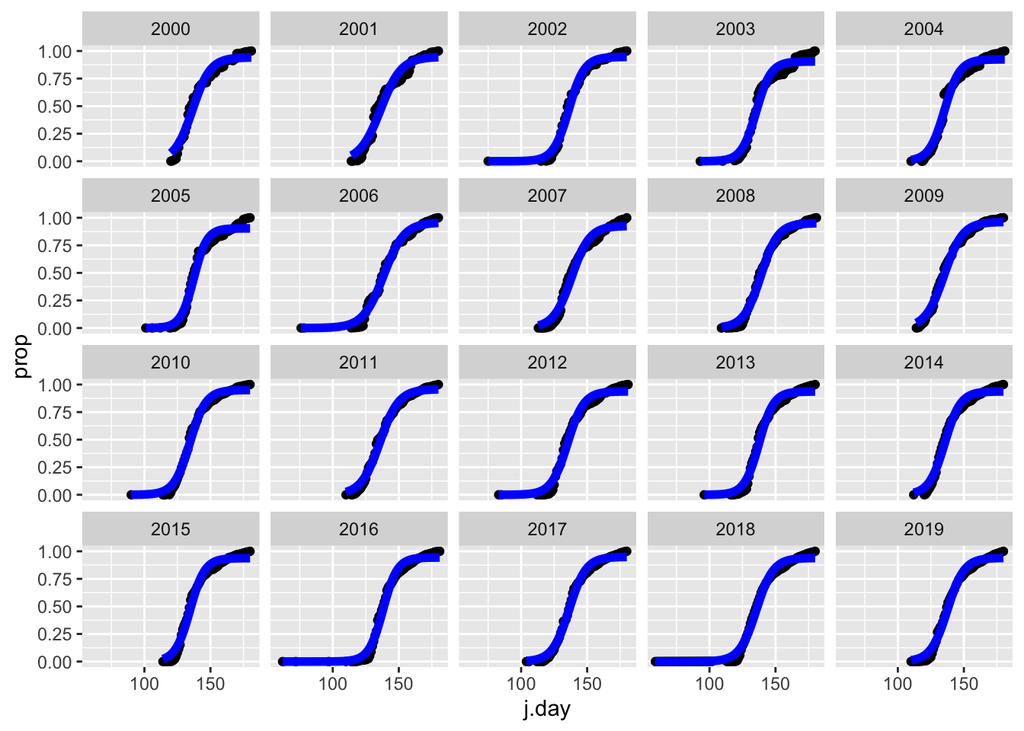

**Fig. 10.** Proportion of the population of *Icterus galbula* that has arrived in Boston, MA by the given Julian day. Logistic models plotted in blue to estimate the arrival date.

The arrival data for *Icterus galbula* is between 125 and 150 Julian days. This date can be closely predicated with a logistical model curve.

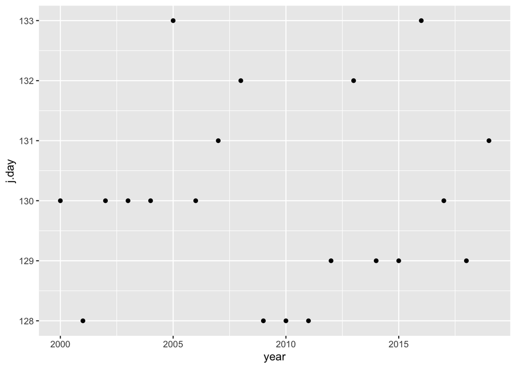

**Fig. 11.** Julian day from each year corresponding to the arrival of 25% of the *Icterus galbula* population to Boston, MA.

When 25% of the TGM species has arrived in Boston, MA, the species can be said to have arrived to its spring range. The arrival dates for *Icterus galbula* are scattered from 128 to 133, but from 2010-2019 have recently shown a slight upward trend toward a higher Julian date.

**Table 4.** Fit values for nested models of the most complicated linear mixed-effect model.

|  | (Intercept) | wk.tmax | wk.tmin | wk.wvec | wk.tmax:wk.tmin | wk.tmax:wk.wvec | wk.tmin:wk.wvec | wk.tmax:wk.tmin:wk.wvec | df | logLik | AICc | delta | weight |
| --- | --- | --- | --- | --- | --- | --- | --- | --- | --- | --- | --- | --- | --- |
| 1 | 132.9296 | -0.0257527 | 0.0275147 | -0.0403493 | NA | NA | NA | NA | 6 | -119.1811 | 251.9472 | 0.00000 | 0.9988023087 |
| 5 | 132.9526 | -0.0241837 | 0.0237568 | -0.0677788 | NA | NA | 0.0002489 | NA | 7 | -125.4415 | 267.0369 | 15.08975 | 0.0005281804 |
| 2 | 139.8945 | -0.0503479 | -0.0597240 | -0.0445613 | 0.0003181 | NA | NA | NA | 7 | -125.7762 | 267.7062 | 15.75906 | 0.0003779572 |
| 3 | 132.8746 | -0.0252854 | 0.0269802 | -0.0475642 | NA | 3.27e-05 | NA | NA | 7 | -126.0358 | 268.2254 | 16.27818 | 0.0002915537 |

The first model shown in the table including minimum temperature, maximum temperature, and wind vector fits this data set best.

## Vireo olivaceus

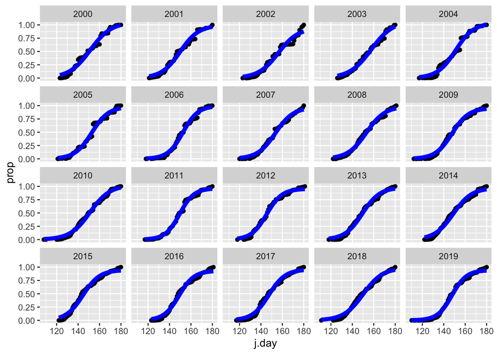

**Fig. 12.** Proportion of the population of *Vireo olivaceus* that has arrived in Boston, MA by the given Julian day. Logistic models plotted in blue to estimate the arrival date.

The arrival data for *Vireo olivaceus* is between 130 and 160 Julian days. This date can be closely predicated with a logistical model curve.

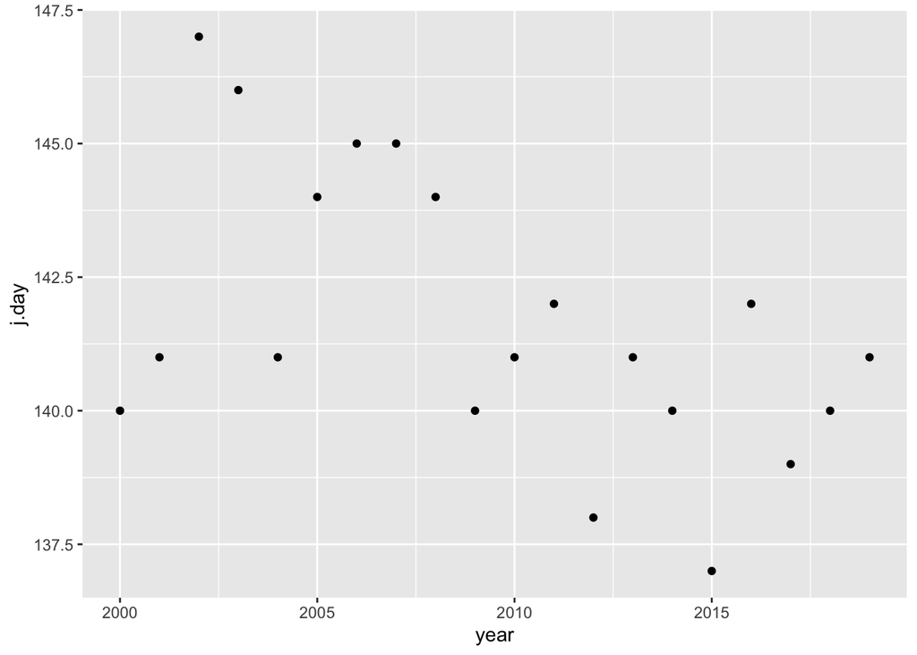

**Fig. 13.** Julian day from each year corresponding to the arrival of 25% of the *Vireo olivaceus* population to Boston, MA.

When 25% of the TGM species has arrived in Boston, MA, the species can be said to have arrived to its spring range. The arrival dates for *Vireo olivaceus* are scattered from 137 to 147, but show a slight downward trend toward a lower Julian date.

**Table 5.** Fit values for nested models of the most complicated linear mixed-effect model.

|  | (Intercept) | wk.tmax | wk.tmin | wk.wvec | wk.tmax:wk.tmin | wk.tmax:wk.wvec | wk.tmin:wk.wvec | wk.tmax:wk.tmin:wk.wvec | df | logLik | AICc | delta | weight |
| --- | --- | --- | --- | --- | --- | --- | --- | --- | --- | --- | --- | --- | --- |
| 1 | 140.3714 | -0.0077510 | 0.0280017 | -0.0937264 | NA | NA | NA | NA | 6 | -148.7632 | 311.1114 | 0.00000 | 0.9928582949 |
| 5 | 140.4445 | 0.0109648 | -0.0107933 | -0.2824405 | NA | NA | 0.0015022 | NA | 7 | -153.0613 | 322.2765 | 11.16509 | 0.0037361012 |
| 2 | 160.9944 | -0.0738484 | -0.1922990 | -0.0844934 | 0.0007331 | NA | NA | NA | 7 | -153.3629 | 322.8797 | 11.76828 | 0.0027633581 |
| 3 | 140.3250 | -0.0008635 | 0.0135708 | -0.2203729 | NA | 0.0005654 | NA | NA | 7 | -154.8221 | 325.7981 | 14.68674 | 0.0006422458 |

The first model shown in the table including minimum temperature, maximum temperature, and wind vector fits this data set best.

This all could have been done in much less code to answer the question. Repeating an analysis for each species misses the point of evaluating the over all pattern.

```r
all.dat<- dat%>%
  group_by(species,year)%>%
  mutate(date=as.Date(paste0(year,"-",month,"-",day)),
         j.day=julian(date,origin=as.Date(paste0(unique(year),"-01-01")))
  )%>%
  group_by(species,year,j.day,date)%>%
  summarise(day.tot=sum(individualCount,na.rm=T))%>%
  group_by(species,year)%>%
  mutate(prop=cumsum(day.tot/sum(day.tot,na.rm = T)))%>%
  filter(year>1999)
all.pred <- all.dat%>%
  group_by(species,year)%>%
  summarize(
    pred=predict(nls(prop~SSlogis(j.day,Asym, xmid, scal)),newdata=data.frame(j.day=min(j.day):max(j.day))),
    j.day=min(j.day):max(j.day),
  )%>%
  left_join(mc%>%dplyr::select(species,j.day,date))
all.arrive.date <-all.pred%>%
  group_by(species,year)%>%
  filter(j.day==j.day[which.min(abs(pred-0.25))])

all.arr.weath2 <- all.arrive.date%>%
  left_join(weather.wk)
all.lmer <- lmer(j.day~wk.tmin*wk.tmax*wk.wvec+(1|name),all.arr.weath2,na.action = "na.fail")
all.arr.aic <- dredge(all.lmer,fixed = c("wk.tmin","wk.tmax","wk.wvec"),)
```

```
## Fixed terms are "wk.tmin", "wk.tmax", "wk.wvec" and "(Intercept)"
```

```r
best.lmer <-  lmer(j.day~wk.tmin+wk.tmax+wk.wvec+(1|name),all.arr.weath2,na.action = "na.fail")

anova(best.lmer)
```

```
## Analysis of Variance Table
##         npar  Sum Sq Mean Sq F value
## wk.tmin    1  736.41  736.41 31.6404
## wk.tmax    1   59.84   59.84  2.5709
## wk.wvec    1 1051.65 1051.65 45.1852
```

```r
grade <- grade-10
```

# Discussion

Through utilizing meteorological and eBird data, the effect of temporal conditions on TGM arrival in Massachusetts were explained upon conducting various linear mixed-effect modeling. In terms of how arrival time varies according to temperature and wind variables, majority of the 5 species analyzed show a general trend of earlier arrival dates since 2000. One notable exception is *Setophaga cerulea*, where a positive correlation can be observed on the year vs. Julian day graph.

In terms of the role that climatic variables play in long-distance migration of birds, previous studies have confirmed that wind vector, specifically tail-winds, are taken into account by long-distance migrants; tail-winds are considered a vital support for long-distance migrants to cover the extensive area that they do (Liechti (2006)). This explains why we found that wind vector was a significant predictor of arrival time in nearly all of the species.

## Author Contributions

Rachel Z: Introduction  
Katherine: Methods  
Rachel R: Results  
Jessica: Discussion

Well done! Great discussion and refs. My only critique . . it could have been a little more concise.

```r
print(grade)
```

```
## [1] 140
```

## References

Baker, Allan J, Patricia M Gonzalez, Theunis Piersma, Lawrence J Niles, Inês de Lima Serrano do Nascimento, Philip W Atkinson, Nigel A Clark, Clive DT Minton, Mark K Peck, and Geert Aarts. 2004. “Rapid Population Decline in Red Knots: Fitness Consequences of Decreased Refuelling Rates and Late Arrival in Delaware Bay.” *Proceedings of the Royal Society of London. Series B: Biological Sciences* 271 (1541): 875–82.

Cook, Aonghais SCP, Niall HK Burton, Stephen G Dodd, Simon Foster, Robert J Pell, Robin M Ward, Lucy J Wright, and Robert A Robinson. 2021. “Temperature and Density Influence Survival in a Rapidly Declining Migratory Shorebird.” *Biological Conservation* 260: 109198.

Liechti, Felix. 2006. “Birds: Blowin’by the Wind?” *Journal of Ornithology* 147 (2): 202–11.

Zaifman, Jay, Daoyang Shan, Ahmet Ay, and Ana Gabriela Jimenez. 2017. “Shifts in Bird Migration Timing in North American Long-Distance and Short-Distance Migrants Are Associated with Climate Change.” *International Journal of Zoology* 2017.